# Homework 1 Solutions

# Open Response

For this exercise, use the **diamonds** dataset in the tidyverse. Use `?diamonds` to get more information about the dataset.

## Step 1: Select 1 numeric variable and 2 categorical variables. Create a graphic using `geom_boxplot()` and `facet_wrap` to illustrate the empirical distributions of the sample.

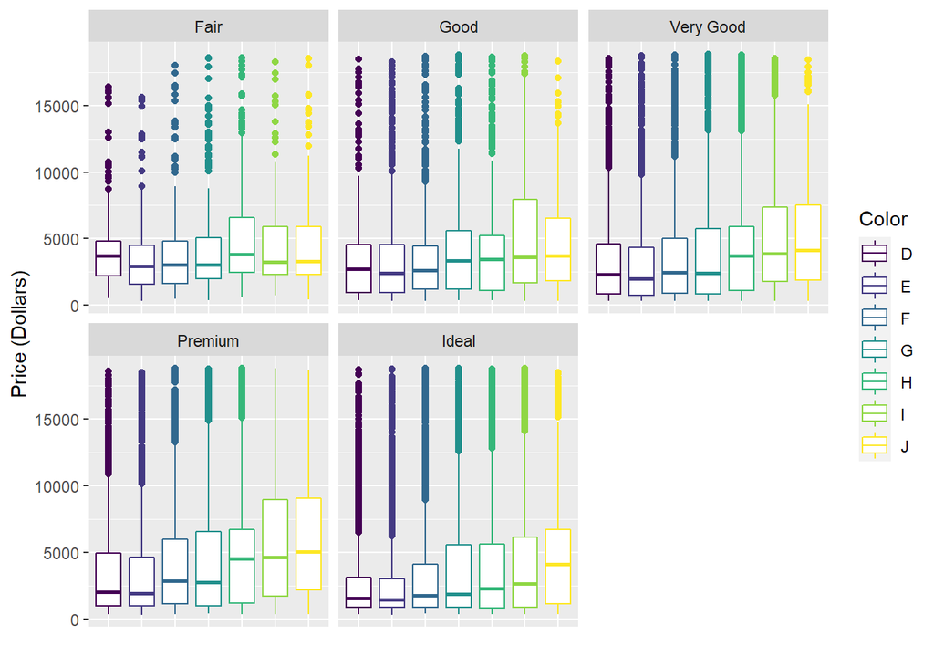

```r
ggplot(data=diamonds) +
  geom_boxplot(aes(x=color,y=price,color=color)) +
  facet_wrap(~cut) +
  theme(axis.text.x=element_blank(),axis.ticks.x=element_blank()) +
  guides(color=guide_legend(title="Color"))+
  xlab("") + ylab("Price (Dollars)")
```

## Step 2: Choose 2 numeric variables and 2 categorical variables and creatively illustrate the relationship between all the variables.

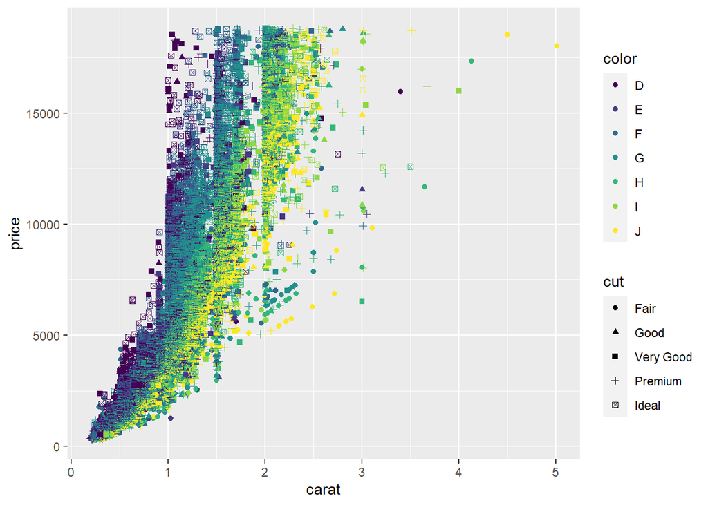

```r
ggplot(data=diamonds) +
  geom_point(aes(x=carat,y=price,shape=cut,color=color))
```